# Assessment WG guidance on providing FLR stock objects to WGMIXFISH

**Required packages to reproduce tutorial:**

```r
# data manipulation and plotting
library(tidyr)
library(dplyr)
library(ggplot2)

# FLR
library(FLCore) # https://github.com/flr/FLCore
library(ggplotFL) # https://github.com/flr/ggplotFL

# SAM
library(stockassessment) # https://github.com/fishfollower/SAM
library(FLfse) # https://github.com/flr/FLfse

# SPiCT
library(spict) # https://github.com/DTUAqua/spict

# to build output
library(knitr)
library(kableExtra)
```

# 1 Introduction

As part of the mixed fishery model conditioning for WGMIXFISH, we need to estimate the catchabilities (*q*) of each fleet/metier/stock interaction to be used in forecasts. For this, we require information on catch and effort data combined with the stock size and productivity. Mixed fishery model forecasts used by WGMIXFISH are currently deterministic, which requires a summary of the of the stock assessment (e.g. median estimates) within a common format; an FLStock object [(FLR, *Fisheries Library in R*)](https://flr-project.org).

WGMIXFISH requests two FLStock objects per stock:

1. The first object (“stock_input”) should contain the observational data used as inputs to the stock assessment model. For catches, this would generally be the raised data exported from InterCatch. For other types of observations such as maturity or natural mortality, please provide the data used as input to the stock assessment model.
2. The second object (“stock_estimated”) should contain all outputs from the stock assessment model. Stock numbers and harvest mortality are clearly estimated by the assessment models, but we are also interested in all other information that might have been estimated (e.g. landings, discards, maturity, natural mortality, etc.).

The input data is of interest in identifying consistencies between reported catches to InterCatch and WGMIXFISH Accessions data. The estimated data is necessary to provide forecasts in the mixed fishery model that are as close as possible to the assumptions of the single stock advice. In some cases this will involve scaling up/down the catches by fleet/metier so that the fleets totals match those of the assessment.

The following sections provide some specific instructions regarding the preparation of FLStock objects for different assessment types: Age-based dynamics, Biomass-based dynamics (i.e. SPiCT surplus production model), and Fixed stocks without dynamics (e.g. Nephrops).

# 2 General FLStock creation

A blank FLStock may be constructed by setting up an FLQuant with the appropriate age and year dimension definitions. It is important to define the Fbar age range manually, and well as units associated with the slots. The example below uses the standard units typical of age-based quantitative assessments.

```r
# make blank FLStock
flq <- FLQuant(0, dimnames=list(age=3:10, year=1967:2022))
stock_estimated <- FLStock(flq)

# name of stock and description of stock object
name(stock_estimated) <- "pok.27.3a46"
desc(stock_estimated) <- "pok.27.3a46 - FLStock containing stock assessment model estimates"

# set Fbar age range
stock_estimated@range[c("minfbar", "maxfbar")] <- c(4,7)

# add units (adjust if necessary)
units(stock_estimated) <- standardUnits(stock_estimated) # add standard units
unlist(units(stock_estimated))
```

```
       catch      catch.n     catch.wt     discards   discards.n  discards.wt
         "t"       "1000"         "kg"          "t"       "1000"         "kg"
    landings   landings.n  landings.wt        stock      stock.n     stock.wt
         "t"       "1000"         "kg"          "t"       "1000"         "kg"
           m          mat      harvest harvest.spwn       m.spwn
         "m"           ""          "f"           ""           ""
```

```r
# summary
stock_estimated
```

```
An object of class "FLStock"

Name: pok.27.3a46
Description: pok.27.3a46 - FLStock containing stock assessment model estimates
Quant: age
Dims:  age  year    unit    season  area    iter
    8   56  1   1   1   1

Range:  min max pgroup  minyear maxyear minfbar maxfbar
    3   10  10  1967    2022    4   7

Metrics:
  rec: NA - NA  (1000)
  ssb: 0 - 0  (t)
  catch: NA - NA  (t)
  fbar: NA - NA  (f)
```

Following this, individual slots may be updated with data. In the following example, a data matrix or array can be passed to the appropriate slot.

```r
# maturity at age
A <- array(c(0.19, 0.35, 0.58, 0.82, 0.94, 0.98, 0.99, 1),
  dim = c(8, 56), dimnames=list(age = 3:10, year = 1967:2022))
A <- FLQuant(A)
stock_estimated@mat <- A
```

# 3 Age-based stocks

Quantitatively-assessed age-based stocks should be able to provide information to all slots (see `?FLStock` for slot details):

```r
slotNames(stock_estimated)
```

```
 [1] "catch"        "catch.n"      "catch.wt"     "discards"     "discards.n"
 [6] "discards.wt"  "landings"     "landings.n"   "landings.wt"  "stock"
[11] "stock.n"      "stock.wt"     "m"            "mat"          "harvest"
[16] "harvest.spwn" "m.spwn"       "name"         "desc"         "range"
```

## 3.1 Direct extraction from SAM using FLfse

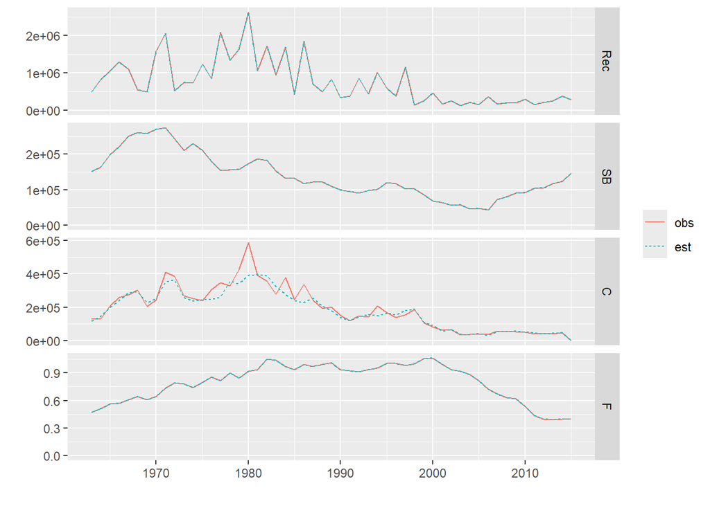

```r
plot(L) + aes(linetype = stock)
```

## 3.2 Quality control checks

Consistency in values should be reviewed, and the following shows some simple tests that should be conducted. For example: 1. the sum of products (SOP) should equal the totals for the stock, landings, and discards ($numbers*weight_{ind} = weight_{total}$), 2. the landings and discards sum up to the catches, 3. individual catch weights (`@catch.wt`) are equal to the weighted mean of the individual landings weight (`@landings.wt`) and discards weight (`@discards.wt`).

Small deviations might be expected if stock objects represent summaries of independent iterations.

```r
# check that sum of product (SOP) calculations equal (or close to)
# aggregate slots (in the best case, all.equal is TRUE)
all.equal(c(discards(stock_estimated)), c(computeDiscards(stock_estimated)))
[1] TRUE
all.equal(c(landings(stock_estimated)), c(computeLandings(stock_estimated)))
[1] TRUE
all.equal(c(catch(stock_estimated)), c(computeCatch(stock_estimated)))
[1] TRUE
all.equal(c(stock(stock_estimated)), c(computeStock(stock_estimated)))
[1] TRUE
all.equal(c(landings(stock_estimated)+discards(stock_estimated)),
  c(catch(stock_estimated)))
[1] "Mean relative difference: 0.0001661268"


# check that the weighted mean of landings.wt and discards.wt equals
# (or is close to) catch.wt
df <- as.data.frame(stock_estimated)
df <- df |> filter(slot %in%
    c("landings.wt", "discards.wt", "landings.n", "discards.n", "catch.wt")) |>
  pivot_wider(names_from = slot, values_from = data)

df <- df |> rowwise() |>
  mutate(catch.wt.calc =
      weighted.mean(c(landings.wt, discards.wt), c(landings.n, discards.n))) %>%
  ungroup()

all.equal(c(df$catch.wt), c(df$catch.wt.calc))
[1] "Mean relative difference: 0.0001093621"
# plot(catch.wt.calc ~ catch.wt, df); abline(0,1)
```

# 4 Biomass-based stocks with dynamics

For those case studies that employ the FLBEIA mixed fisheries modelling framework (Bay of Biscay, Iberian Waters, North Sea), stocks with biomass-based dynamics (i.e. surplus production model) may be specified. The most common model used in ICES is SPiCT (*Surplus Production model in Continuous Time*). SPiCT parameters are translated into FLBEIA using the approach adapted from the following FLR tutorial, *Conditioning FLBEIA in Data Limited Situations* (https://flr-project.org/doc/FLBEIA_Data_Poor_MSE.html)

The following function, `spict2flbeia`, is used to convert a SPiCT object to a yearly FLStock object. In addition, the function translates the Pella-Tomlinson parameters to the formulation used by FLBEIA. You are welcome to submit your full SPiCT object directly to WGMIXFISH (unless the fitted SPiCT object file is especially large), whereby we can make this conversion. Nevertheless, feel free to examine the following function and notify us of any inconsistencies.

Currently, there is only a single example of incorporating a stock with biomass dynamics in WGMIXFISH (North Sea brill, bll.27.3a47de), although more are likely to come. If SPiCT assessments exist in other case study areas that do not use FLBEIA, the FLStock can still be provided as the basis for inclusion as a fixed stock without biomass dynamics (i.e. using the SPiCT-produced forecast information).

`spict2flbeia` function (*click ‘Show’ to expand*):

```r
#' Extract FLStock and biomass dynamics parameters from spict object
#'
#' @description
#' The `spict2flbeia` will extract FLStock and biomass dynamics parameters
#'   from a spict object. As there are no individual weights in surplus
#'   production models, the function assigns a value of 1.0 to all individual
#'   weight slots (`@stock.wt`, `@catch.wt`, `@landings.wt`, `@discards.wt`).
#'   Individual numbers slots (`@stock.n`, `@catch.n`, `@landings.n`,
#'   `@discards.n`) are thus identical to the the sum of products slots
#'   (`@stock`, `@catch`, `@landings`, `@discards`)
#'
#'
#' @param spict_fit fitted spict object fit with \code{\link[spict]{fit.spict}}
#' @param wt_units character. Units to apply to individual weight at age.
#'   Default is "kg", which when combined with with argument `n_units`
#'   (Default "10^3"), will describe the sum of products (e.g. "t")
#' @param n_units character. Units to apply to individual numbers at age
#'   (Default "10^3").
#' @param catch_units character. Units to apply to catches (Default "t").
#' @param stock_name character. Name of stock (Optional, Default = "stk")
#' @param disc numeric vector. Optional vector of discard values. Default
#'   assumes zero discards.
#'
#' @return list. Results contain an FLStock object (`$stk`) and biomass dynamics
#'   parameters required for conditioning those types of stocks in FLBEIA
#'   (`$BDinfo`); in particular, Pella-Tomlinson parameters
#'   (`$BDinfo$PellaTomlinson_pars`) and reference points (`$BDinfo$refPts`)
#'
#' @export
#'
spict2flbeia <- function(
  spict_fit, # fitted spict object
  wt_units = "kg", # units for weight at age
  n_units = "10^3", # units for numbers
  catch_units = "t", # units for catch
  stock_name = "stk", # optional stock name
  disc = NULL # discard time series
){

  # extract biomass and make FLStock
  Bs <- as.data.frame(get.par("logB", spict_fit, exp = TRUE))
  Bs$time <- as.numeric(rownames(Bs))
  Bs$year <- floor(Bs$time)
  yrs <- sort(unique(Bs$year))
  tmp <- data.frame(year = yrs)
  tmp$B <- Bs$est[match(tmp$year, Bs$time)]
  flq <- FLQuant(tmp$B, dim=c(1,nrow(tmp)), dimnames=list(age=1, year=tmp$year), units="t")

  stock <- FLStock(stock=flq, name = stock_name)
  stock@stock.wt[1,] <- 1
  stock@stock.n <- stock@stock / stock@stock.wt
  stock@stock.wt@units <- wt_units
  stock@stock.n@units <- n_units

  # F or harvest rate (averaged over year)
  Fs <- as.data.frame(get.par("logF", spict_fit, exp = TRUE))
  Fs$time <- as.numeric(rownames(Fs))
  Fs$year <- floor(Fs$time)
  tmp <- aggregate(Fs$est, list(year=Fs$year), FUN = mean) # take mean over year?
  names(tmp)[which(names(tmp)=="x")] <- "f"
  stock@harvest[,ac(yrs)] <- tmp$f[match(yrs, tmp$year)]
  stock@harvest@units <- "f"

  # catches
  Cs <- as.data.frame(get.par("logB", spict_fit, exp = TRUE) *
      get.par("logF", spict_fit, exp = TRUE) *
      spict_fit$inp$dt)
  Cs$time <- as.numeric(rownames(Cs))
  Cs$year <- floor(Cs$time)
  tmp <- aggregate(Cs$est, list(year=Cs$year), FUN = sum)
  names(tmp)[which(names(tmp)=="x")] <- "catch"

  stock@catch[,ac(yrs)] <- tmp$catch[match(yrs, tmp$year)]
  stock@catch.wt[,] <- 1
  stock@catch.n[] <- c(stock@catch / stock@catch.wt)
  stock@catch@units <- catch_units
  stock@catch.wt@units <- wt_units
  stock@catch.n@units <- n_units

  # discards
  if(!is.null(disc)){
    stock@discards[,ac(yrs)] <- disc
  }else{
    stock@discards[,ac(yrs)] <- 0
  }
  stock@discards.wt[1,] <- 1
  stock@discards.n[] <- c(stock@discards / stock@discards.wt)
  stock@discards@units <- catch_units
  stock@discards.wt@units <- wt_units
  stock@discards.n@units <- n_units

  # landings
  stock@landings <- stock@catch - stock@discards
  stock@landings.wt[1,] <- 1
  stock@landings.n[] <- c(stock@landings / stock@landings.wt)
  stock@landings@units <- catch_units
  stock@landings.wt@units <- wt_units
  stock@landings.n@units <- n_units

  ## Other pars (not relevant?) ===============================
  stock@mat[1,] <- 1
  stock@harvest.spwn[1,] <- 0
  stock@m[1,] <- 0
  stock@m.spwn[1,] <- 0


  # create BD data for FLBEIA ----------------------------------------------

  tab1 <- sumspict.parest(spict_fit)
  tab3 <- sumspict.states(spict_fit) # intermediate year
  tab5 <- sumspict.predictions(spict_fit) # forecast

  r.stk <- (get.par("logm", spict_fit, exp=T)[2]*
      get.par("logn", spict_fit, exp=T)[2]^
      (get.par("logn", spict_fit, exp=T)[2]/
          (get.par("logn", spict_fit, exp=T)[2]-1)))/
    get.par("logK", spict_fit, exp=T)[2]
  K.stk <- get.par("logK", spict_fit, exp=T)[2]
  p.stk <- get.par("logn", spict_fit, exp=T)[2] - 1

  res <- list()
  res$stk <- stock
  res$BDinfo$par.fixed <- spict_fit$par.fixed
  res$BDinfo$cov.fixed <- spict_fit$cov.fixed
  res$BDinfo$PellaTomlinson_pars <- c("r"=r.stk, "K"= K.stk, "p"=p.stk)

  # Add reference points
  res$BDinfo$refPts <- c(
    "Fmsy" = get.par("logFmsy", spict_fit, exp = TRUE)[,"est"],
    "Bmsy" = get.par("logBmsy", spict_fit, exp = TRUE)[,"est"],
    "MSY" = get.par("MSY", spict_fit)[,"est"]
  )

  return(res)
}
```

## 4.1 Quality control checks

The `spict2FLBEIA` function currently retrieves estimated values for constructing a `stock_estimated` FLStock object. However, input catch can be easily recovered from the fitted spict object (e.g. `fit$inp`). The following plots show the extracted yearly time series for biomass (here labeled *SSB*), catch, and F closely matching the continuous time estimates of SPiCT. Note that the extracted FLStock contains the forecasted years as well.

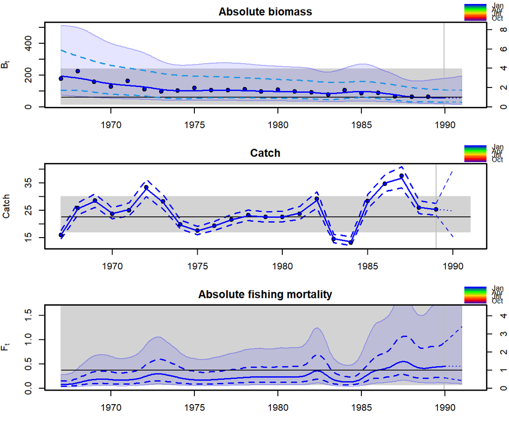

```r
# example spict fit
data(pol)
fit <- fit.spict(pol$albacore)

# extract spict estimate
res <- spict2flbeia(spict_fit = fit)
stock_estimated <- res$stk
op <- par(mfcol = c(3,1), mar = c(3,4,2,2))
plotspict.biomass(fit)
plotspict.catch(fit)
plotspict.f(fit)
```

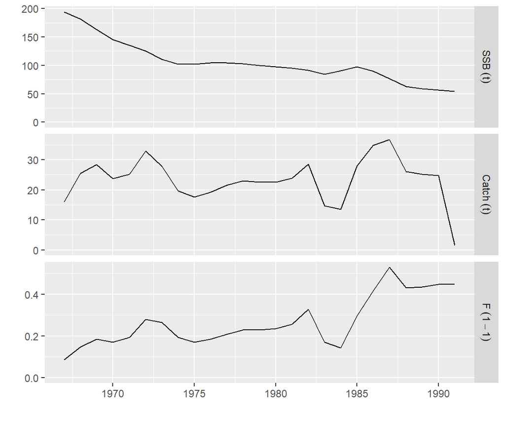

```r
par(op)

# compare FLStock
plot(stock_estimated, metrics = list(SSB = ssb, Catch = catch, F = fbar))
```

# 5 Fixed stocks without dynamics (e.g. Nephops)

For stocks without an quantitative assessment, only a “stock_input” object is requested.

The following examples show how to set up an FLStock object using historical data, either through the manual filling of an empty FLStock object or import via a data.frame. Please feel free to suggest any changes to the process, including any special considerations for specific NEP functional units (FUs).

## 5.1 Direct setup through manual entry

In the direct setup, one first begins with an empty FLStock object, defined by a single age and the number of years. In this example, data is taken from summary Table 5 of the [Nephrops FU6 2020 advice](https://doi.org/10.17895/ices.advice.5840).

The procedure is the same as that presented in the *General FLStock creation* section, but only a single age class is defined and the units of the slots are also adjusted from the standard units. Contrary to the biomass-based example, where the individual weights are held constant at 1.0 (e.g. `@stock.wt`, `catch.wt`), Nephrops stocks may contain yearly changes in individual weights.

```r
# make blank FLStock
flq <- FLQuant(0, dimnames=list(age=1, year=2001:2019))
stock_input <- FLStock(flq)

# name of stock and description of stock object
name(stock_input) <- "nep.FU6"
desc(stock_input) <- "nep.FU6 - FLStock containing stock assessment model input"

# add and adjust units
units(stock_input) <- standardUnits(stock_input) # add standard units

# NEP units are typically non-standard for numbers, ind. weights, and harvest
units(stock_input@catch.n) <- units(stock_input@landings.n) <-
  units(stock_input@discards.n) <-
  units(stock_input@stock.n) <- "1e6" # millions
units(stock_input@catch.wt) <- units(stock_input@landings.wt) <-
  units(stock_input@discards.wt) <-
  units(stock_input@stock.wt) <- "g" # grams
units(harvest(stock_input)) <- "hr" # harvest rate (proportion)

# summary
stock_input
```

```
An object of class "FLStock"

Name: nep.FU6
Description: nep.FU6 - FLStock containing stock assessment model input
Quant: age
Dims:  age  year    unit    season  area    iter
    1   19  1   1   1   1

Range:  min max pgroup  minyear maxyear minfbar maxfbar
    1   1   1   2001    2019    1   1

Metrics:
  rec: NA - NA  (1e6)
  ssb: 0 - 0  (t)
  catch: NA - NA  (t)
  fbar: NA - NA  (hr)
```

Then, one fills in the values by hand. The important slots include the **numbers** and **individual weights** for landings, discards, and the stock (where available). Other missing values may be inferred or calculated. Here, several slots are filled in via calculation, but it’s best to fill in as many raw values as possible as provided by the assessment, which can be subsequently compared to computed values (e.g. via `computeCatch`, `computeLandings`, `computeDiscards`, `computeHarvest` functions).

For Nephrops stocks without stock estimates, see later section *Other considerations for Nephrops FUs without survey estimates*

```r
## Main numbers, ind. weight, and tot. weight slots

stock_input@landings[] <- c(2574, 1953, 2245, 2153, 3094, 4903, 2966, 1220,
  2713, 1443, 2070, 2460, 2982, 2503, 1371, 1854, 1963, 1807, 4359)
stock_input@landings.wt[] <- c(21, 20, 22, 23, 24, 23, 25, 27, 24, 25, 27, 27,
  28, 30, 29, 28, 29, 29, 28)
stock_input@landings.n[] <- stock_input@landings / stock_input@landings.wt

# discard ratio (dead discards)
DR <- c(67, 46, 42, 42, 35, 31, 25, 25, 29, 23, 23, 27, 30, 14.9, 29, 29,
  22, 21, 20)/100
stock_input@catch.n[] <- stock_input@landings.n / (1-DR)
stock_input@discards.n[] <- stock_input@catch.n - stock_input@landings.n
stock_input@discards.wt[] <- c(9.6, 9.5, 9.6, 9.2, 10.3, 10.6, 10.9, 11, 10.5,
  11.7, 11, 10.2, 9.8, 13.6, 10, 10.2, 10.3, 11.2, 11.6)
stock_input@discards <- computeDiscards(stock_input)

# apply weighted mean of landings.wt and discards.wt for catch.wt
stock_input@catch.wt <- (stock_input@landings.wt * stock_input@landings.n +
    stock_input@discards.wt * stock_input@discards.n) /
  (stock_input@landings.n + stock_input@discards.n)
stock_input@catch <- computeCatch(stock_input)

# stock - survey estimate, stock.wt same as catch.wt
stock_input@stock.n[] <- c(1685, 1048, 1085, 1377, 1657, 1244, 858, 987, 682,
  785, 878, 758, 706, 755, 565, 697, 902, 950, 1163)
stock_input@stock.wt <- stock_input@catch.wt
stock_input@stock <- computeStock(stock_input)

# harvest rates
stock_input@harvest[] <- c(20, 16.1, 15.3, 10.9, 11.5, 24, 17.8, 5.9, 22, 9.2,
  10.9, 15.7, 21, 12.7, 11.1, 12.8, 9.3, 8.1, 16.1)/100

# less essential slots (but needed to calculate ssb in summary plot)
stock_input@mat[] <- 1
stock_input@harvest.spwn[1,] <- 0
stock_input@m[1,] <- 0
stock_input@m.spwn[1,] <- 0
```

## 5.2 Indirect setup through import

If you are more comfortable organizing the data outside R first, e.g. in a worksheet, it is also possible to import these values into an FLStock object. The following example shows this process.

One can first start with a data.frame of imported FLStock slot values as columns. For demonstration purposes, this starting data.frame is simply based on the above stock_input object, with some slots removed. It is important the that column names are consistent with names of FLStock slots.

```r
# read in data (i.e. read.csv, read.table)
df <- as.data.frame(stock_input)
df <- df |> filter(!slot %in% c("m", "mat", "harvest.spwn", "m.spwn"))
df <- df |> pivot_wider(id_cols = year, names_from = slot, values_from = data)
df
```

| year | catch | catch.n | catch.wt | discards | discards.n | discards.wt | landings | landings.n | landings.wt | stock | stock.n | stock.wt | harvest |
| --- | --- | --- | --- | --- | --- | --- | --- | --- | --- | --- | --- | --- | --- |
| 2001 | 4963.029 | 371.42857 | 13.3620 | 2389.0286 | 248.85714 | 9.6 | 2574 | 122.57143 | 21 | 22514.97 | 1685 | 13.3620 | 0.200 |
| 2002 | 2743.242 | 180.83333 | 15.1700 | 790.2417 | 83.18333 | 9.5 | 1953 | 97.65000 | 20 | 15898.16 | 1048 | 15.1700 | 0.161 |
| 2003 | 2954.392 | 175.94044 | 16.7920 | 709.3918 | 73.89498 | 9.6 | 2245 | 102.04545 | 22 | 18219.32 | 1085 | 16.7920 | 0.153 |
| 2004 | 2776.628 | 161.39430 | 17.2040 | 623.6276 | 67.78561 | 9.2 | 2153 | 93.60870 | 23 | 23689.91 | 1377 | 17.2040 | 0.109 |
| 2005 | 3808.992 | 198.33333 | 19.2050 | 714.9917 | 69.41667 | 10.3 | 3094 | 128.91667 | 24 | 31822.69 | 1657 | 19.2050 | 0.115 |
| 2006 | 5918.202 | 308.94770 | 19.1560 | 1015.2021 | 95.77379 | 10.6 | 4903 | 213.17391 | 23 | 23830.06 | 1244 | 19.1560 | 0.240 |
| 2007 | 3397.059 | 158.18667 | 21.4750 | 431.0587 | 39.54667 | 10.9 | 2966 | 118.64000 | 25 | 18425.55 | 858 | 21.4750 | 0.178 |
| 2008 | 1385.679 | 60.24691 | 23.0000 | 165.6790 | 15.06173 | 11.0 | 1220 | 45.18519 | 27 | 22701.00 | 987 | 23.0000 | 0.059 |
| 2009 | 3197.805 | 159.21362 | 20.0850 | 484.8055 | 46.17195 | 10.5 | 2713 | 113.04167 | 24 | 13697.97 | 682 | 20.0850 | 0.220 |
| 2010 | 1644.720 | 74.96104 | 21.9410 | 201.7202 | 17.24104 | 11.7 | 1443 | 57.72000 | 25 | 17223.68 | 785 | 21.9410 | 0.092 |

[output cut: 9 more lines]

The data must then be adapted to “long” format, followed by conversion to an FLStock class with `as.FLStock`. Subsequently, the same care must be made to check the definition of slot units.

```r
# convert to "long" format
mdf <- df |> pivot_longer(cols = !year, names_to = "slot", values_to = "data")

# add age = 1
mdf$age <- "1"

# convert to FLStock
stock_input <- as.FLStock(mdf)

# name of stock and description of stock object
name(stock_input) <- "nep.FU"
desc(stock_input) <- "nep.FU - FLStock containing stock assessment model input"


# add and adjust units
units(stock_input) <- standardUnits(stock_input) # add standard units

# NEP units are typically non-standard for numbers, ind. weights, and harvest
units(stock_input@catch.n) <- units(stock_input@landings.n) <-
  units(stock_input@discards.n) <-
  units(stock_input@stock.n) <- "1e6" # millions
units(stock_input@catch.wt) <- units(stock_input@landings.wt) <-
  units(stock_input@discards.wt) <-
  units(stock_input@stock.wt) <- "g" # grams
units(harvest(stock_input)) <- "hr" # harvest rate (proportion)

## less essential slots (but needed to calculate ssb in summary plot)
stock_input@mat[] <- 1
stock_input@harvest.spwn[1,] <- 0
stock_input@m[1,] <- 0
stock_input@m.spwn[1,] <- 0
```

## 5.3 Quality control checks

As in the previous examples, a summary plot is a good first step to visualise the resulting object.

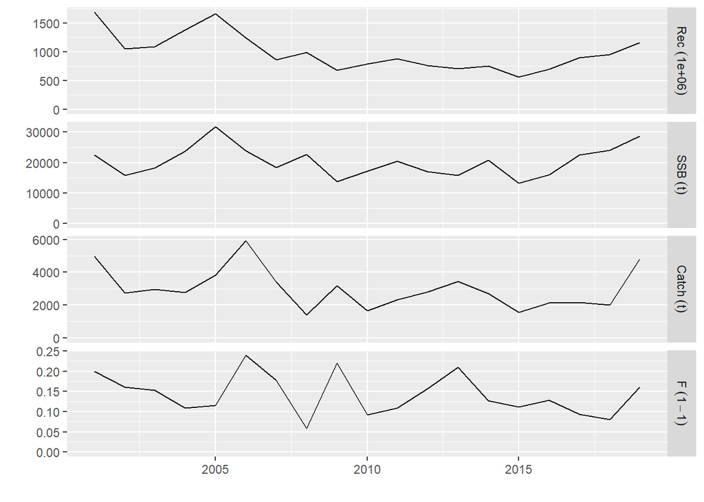

```r
plot(stock_input)
```

Again, quality control checks should be conducted. For example: 1. the sum of products (SOP) should equal the totals for the stock, landings, and discards ($numbers*weight_{ind} = weight_{total}$), 2. the landings and discards sum up to the catches, 3. harvest rates should reflect the ratio of catch / stock (`computeHarvest` will calculate this ratio if `@harvest` units have correctly been defined as “hr”).

Small deviations might be attributable to rounding errors (e.g. in this case as values were taken from the advice summary table), thus the original precision should be used in the FLStock when possible.

```r
# check that sum of product (SOP) calculations equal (or close to)
# aggregate slots (in the best case, all.equal is TRUE)
all.equal(c(discards(stock_input)), c(computeDiscards(stock_input)))
[1] TRUE
all.equal(c(landings(stock_input)), c(computeLandings(stock_input)))
[1] TRUE
all.equal(c(catch(stock_input)), c(computeCatch(stock_input)))
[1] TRUE
all.equal(c(stock(stock_input)), c(computeStock(stock_input)))
[1] TRUE
all.equal(c(landings(stock_input)+discards(stock_input)),
  c(catch(stock_input)))
[1] TRUE

# check that the weighted mean of landings.wt and discards.wt equals
# (or is close to) catch.wt
df <- as.data.frame(stock_input)
df <- df |>
  pivot_wider(names_from = slot, values_from = data)

df <- df |> rowwise() |>
  mutate(catch.wt.calc =
      weighted.mean(c(landings.wt, discards.wt), c(landings.n, discards.n))) %>%
  ungroup()

all.equal(c(df$catch.wt), c(df$catch.wt.calc))
[1] TRUE
# plot(catch.wt.calc ~ catch.wt, df); abline(0,1)

# since we only have a single age group, should stock.wt equal to catch.wt?
all.equal(c(catch.wt(stock_input)), c(stock.wt(stock_input)))
[1] TRUE

# if harvest rates are reported, do they align with the ratio of catch/stock
# are inconsistencies related to survival rates for discards?
all.equal(c(harvest(stock_input)), c(computeHarvest(stock_input)))
[1] "Mean relative difference: 0.04895297"
tmp <- data.frame(year = df$year, harvest_rate = df$harvest, "catch_stock" = df$catch / df$stock)
tmp
```

| year | harvest_rate | catch_stock |
| --- | --- | --- |
| 2001 | 0.200 | 0.22043239 |
| 2002 | 0.161 | 0.17255089 |
| 2003 | 0.153 | 0.16215709 |
| 2004 | 0.109 | 0.11720719 |
| 2005 | 0.115 | 0.11969423 |
| 2006 | 0.240 | 0.24835024 |
| 2007 | 0.178 | 0.18436674 |
| 2008 | 0.059 | 0.06104044 |
| 2009 | 0.220 | 0.23345105 |
| 2010 | 0.092 | 0.09549177 |

[output cut: 9 more lines]

## 5.4 Other considerations for Nephrops FUs without survey estimates

If there is no information on the stock numbers and individual weights, as is the case for Nephrops stocks without annual TV-surveys of abundance, you will still need to provide values in order to conditioning the mixed fishery model. Given that we use fixed dynamics for Nephrops in the WGMIXFISH forecasts, this adjustment will not affect dynamics and is only used for the calculation of catchability rates.

What we have done until now is to first assume that the individual stock weight, `stock_input@stock.wt`, is equivalent to that of the catch, `stock_input@catch.wt`. For stock numbers, we are mainly concerned with supplying values high enough so that they are not exceeded by the catch numbers (in which case, our model would return `NA` and likely crash). In order to avoid this, we can set a value that is sufficiently higher (e.g. *10x* higher `stock_input@stock.n <- stock_input@catch.n * 10`). Again, since dynamics are fixed, this is done primarily for the stability of the model and the choice of the multiplier is somewhat arbitrary. Unless specific objections are presented, we recommend using a multiplier of `10`, which translates to a somewhat realistic harvest rate of 10%.

# 6 Requested stocks

| WG | stocks |
| --- | --- |
| WGNSSK | cod.27.47d20, had.27.46a20, ple.27.7d, ple.27.420, pok.27.3a46, sol.27.7d, sol.27.4, tur.27.4, whg.27.47d, wit.27.3a47d, nep.fu.5, nep.fu.6, nep.fu.7, nep.fu.8, nep.fu.9, nep.fu.10, nep.fu.32, nep.fu.… |
| WGCSE | cod.27.7a, cod.27.7e-k, had.27.7a, had.27.7bce-k, ple.27.7a, sol.27.7a, sol.27.7e, sol.27.7fg, whg.27.7a, whg.27.7bce-k, nep.fu.14, nep.fu.15, nep.fu.16, nep.fu.17, nep.fu.19, nep.fu.20-21, nep.fu.22,… |
| WGBIE | ank.27.78abd, ank.27.8c9a, bss.27.8ab, hke.27.3a46-8abd, hke.27.8c9a, ldb.27.8c9a, meg.27.7b-k8abd, meg.27.8c9a, mon.27.8c9a, mon.27.78abd, pol.27.89a, sol.27.8ab, whg.27.89a, nep.fu.23, nep.fu.24, ne… |
| other_WG | whb.27.1-91214, hom.27.2a4a5b6a7a-ce-k8, mac.27.nea, sdv.27.nea, rjc.27.8abd, rjn.27.678abd, rju.27.8ab |

## 6.1 Stock specific requests

WGMIXFISH request the following additional information:

1. **had.27.46a20:** Please provide text files containing the mean weights-at-age used in the forecast for the stock, catch, landings and discards.
2. **sol.27.7a:** Please send the raised catch data (processed outside of InterCatch) directly to Ruth Kelly (ruth.kelly@afbini.gov.uk).
3. **ank.27.8c9a:** Please send stock information in an excel spreadsheet directly to Hugo Mendes (hmendes@ipma.pt).
4. **WGBIE: ank.27.78abd, meg.27.7b-k8abd, mon.27.78abd, bss.27.8ab:** Please provide information on the landings and discards data by country used for the assessment in the last few years, at least for 2019-2022 for the ICES Divisions 8.a-b and 8.d (combine and report as Subarea 8) by country, and the totals for all countries in all the rest of the areas (combine and report as “oth”). An example table is given below. This information will be used for comparison with the information from other data sources used at WGMIXFISH.

| stock | year | category | country | area | tonnes |
| --- | --- | --- | --- | --- | --- |
| ANK | 2019 | Landings | Belgium | 8 | 999 |
| ANK | 2019 | Discards | Belgium | 8 | 999 |
| ANK | 2019 | Landings | all | oth | 999 |
| ANK | 2019 | Discards | all | oth | 999 |
| ANK | 2020 | Landings | Belgium | 8 | 999 |
| ANK | 2020 | Discards | Belgium | 8 | 999 |

# 7 Software Versions

- R version 4.4.2 (2024-10-31 ucrt)
- tidyr: 1.3.2
- dplyr: 1.1.4
- FLCore: 2.6.21
- ggplotFL: 2.7.0.9144
- spict: 1.3.8
- stockassessment: 0.12.0
- FLfse: 1.0.2
- **Compiled**: 2026-Jul-01